# Scaling up DNA barcoding – Primer sets for simple and cost efficient arthropod systematics by multiplex PCR and Illumina amplicon sequencing - Krehenwinkel - 2018 - Methods in Ecology and Evolution - 

[Methods in Ecology and Evolution](https://besjournals.onlinelibrary.wiley.com/journal/2041210x)

[Volume 9, Issue 11](https://besjournals.onlinelibrary.wiley.com/toc/2041210x/2018/9/11) p. 2181-2193

RESEARCH ARTICLE

Free Access

# Scaling up DNA barcoding – Primer sets for simple and cost efficient arthropod systematics by multiplex PCR and Illumina amplicon sequencing

[Henrik Krehenwinkel](https://besjournals.onlinelibrary.wiley.com/authored-by/ContribAuthorRaw/Krehenwinkel/Henrik),

[Susan R. Kennedy](https://besjournals.onlinelibrary.wiley.com/authored-by/ContribAuthorRaw/Kennedy/Susan+R.),

[Alexandra Rueda](https://besjournals.onlinelibrary.wiley.com/authored-by/ContribAuthorRaw/Rueda/Alexandra),

[Athena Lam](https://besjournals.onlinelibrary.wiley.com/authored-by/ContribAuthorRaw/Lam/Athena),

[Rosemary G. Gillespie](https://besjournals.onlinelibrary.wiley.com/authored-by/ContribAuthorRaw/Gillespie/Rosemary+G.),

First published: 13 July 2018

https://doi.org/10.1111/2041-210X.13064

Citations: 16

## Abstract

1. The simplicity and cost efficiency of Illumina amplicon sequencing has greatly contributed to the advancement of DNA barcoding and metabarcoding applications. However, current amplicon sequencing-based barcoding approaches are usually restricted to short, single-locus fragments, limiting their taxonomic and phylogenetic resolution.
2. Here, we establish a cost efficient and simple multiplex PCR protocol for arthropod systematics by Illumina amplicon sequencing. We introduce primer sets, including several new, generic primers, to reliably amplify nine loci across a wide range of arthropods. Using a diverse collection of arthropod species from 19 orders, we test loci for amplification efficiency and estimate the effect of cross-species amplification bias on taxon recovery from bulk community samples. We then explore the taxonomic and phylogenetic utility of the primer sets, focusing on a dataset of spiders that includes both deep and recent divergences.
3. The set of loci provides good phylogenetic support across a wide taxonomic spectrum, making it a useful addition to COI for resolving lineages within a comparative context. All loci recover sequences for the majority of arthropod taxa in separate PCRs. However, cross-species amplification bias in some primers prevents an exhaustive taxon recovery from bulk community samples.
4. Our protocol makes it possible to generate multilocus datasets for large numbers of arthropod taxa for a fraction of the price and workload of Sanger sequencing. This opens up the possibility for parallel phylogenetic and taxonomic analysis of large collections of arthropods, but also enables rapid exploratory analyses of target lineages. Primers for metabarcoding applications should be carefully evaluated for their performance in bulk community samples and chosen to minimize cross-species amplification bias.

## 1 INTRODUCTION

In light of the current biodiversity crisis (Hochkirch, 2016), molecular barcoding has developed as an irreplaceable tool for biodiversity exploration (Cristescu, 2014). Based on taxonomically informative DNA sequences, barcoding makes it possible to rapidly assess the species composition of a given locality or quantify the turnover of species in space and time. A short sequence stretch of the mitochondrial Cytochrome Oxidase subunit I (COI) has become one of the most widely used barcoding markers for animals (Hebert, Cywinska, & Ball, 2003). COI usually performs well in taxonomic assignments. However, its utility for the analyses of community diversity and understanding mechanisms involved in patterns of biodiversity (Graham & Fine, 2008) is limited for 3 primary reasons: (a) rapid saturation means that broad-scale phylogenetic utility is limited (Kjer, Zhou, Frandsen, Thomas, & Blahnik, 2014); (b) high mutation rates can lead to unreliability of primers across taxonomic scales (Deagle, Jarman, Coissac, Pompanon, & Taberlet, 2014); and (c) single gene trees often do not reflect the genealogy of species (Avise, 1989; Ortiz & Francke, 2016). Considering this background, multilocus approaches are critical for both DNA barcoding and community-wide phylogenetic analyses.

Traditionally, multilocus molecular systematic work relied on Sanger sequencing, an approach which is still widely used and often yields good phylogenetic resolution (Dimitrov et al., 2017; Lüddecke et al., 2017). However, the cost and associated effort multiply with the number of targeted loci and specimens. As a result, the throughput of Sanger sequencing reaches its practical limitation when high numbers of loci or large specimen collections must be analysed.

In recent years, the emergence of next-generation sequencing (NGS) technology has greatly increased the available marker density in molecular systematics. Phylogenetic and taxonomic hypotheses can now be based on thousands of loci (McCormack et al., 2012; Peterson, Weber, Kay, Fisher, & Hoekstra, 2012), a development which has greatly contributed to the resolution of the tree of life (Misof et al., 2014). However, the generation of such high-density datasets requires complex library preparation and is expensive due to high sequencing effort. Moreover, the analysis of genome-scale datasets requires large computational resources. Consequently, high-throughput methods are also not economically feasible for processing large numbers of species, as required for community-wide collections.

Several approaches have been developed to address the issue of sequencing at scale. Genome skimming has recently gained popularity, as it allows the assembly of plastid or mitochondrial genomes from bulk multi-taxon samples (Coissac, Hollingsworth, Lavergne, & Taberlet, 2016; Dodsworth, 2015). But as it only uses a small proportion of the sequenced DNA (e.g., the mitochondrial DNA), this method requires high sequencing effort and is also relatively costly (Cruaud, Rasplus, Rodriguez, & Cruaud, 2017). Illumina amplicon sequencing is another approach used for high-throughput sequencing, and which has achieved popularity due to its simplicity and cost effectiveness (Gohl et al., 2016). Simple PCR amplification of the target locus, followed by an indexing PCR, completes the library preparation. The high accuracy, throughput and multiplexing capabilities of Illumina sequencing make it possible to process thousands of samples in a single sequencing run (Meier, Wong, Srivathsan, & Foo, 2016). In contrast to genome skimming, only the target locus is sequenced, leading to a considerable reduction of the required read depth. Amplicon sequencing is now routinely used for the generation of DNA barcodes (Shokralla et al., 2015). Another popular application is metabarcoding, in which the diversity of whole communities is assessed (Yu et al., 2012) or feeding interactions resolved (Krehenwinkel, Kennedy, Pekár, & Gillespie, 2017) by sequencing DNA from bulk specimen pools. However, amplicon sequencing-based barcoding and metabarcoding approaches usually rely on information from short sequences of single loci (e.g., COI in animals), resulting in limited taxonomic and phylogenetic resolution (Meier et al., 2016).

For broad-scale community assessment of biodiversity, amplicon sequencing has the potential to provide a cost-effective approach but would have to be scaled up to generate multilocus datasets (Cruaud et al., 2017). In so doing, independent information from multiple loci may also contribute to more accurate estimates of biodiversity in metabarcoding studies (Deagle et al., 2014). Indeed, amplicon sequencing is particularly well suited for multilocus approaches as it allows the direct sequencing of multiplex PCRs. Thus, multilocus data can be generated without a considerable increase in workload compared to single locus barcoding.

Ideally, such multilocus approaches should allow the targeting of a large number of taxa, without having to extensively modify the protocols. Suitable markers should thus show a broad taxonomic specificity and minimize amplification bias between taxa. The latter consideration is particularly important for metabarcoding applications, where amplification bias can lead to skewed diversity estimates or the dropout of taxa from an analysis (Krehenwinkel, Wolf, et al., 2017). Moreover, the maximal paired read length of 300 bp of Illumina sequencing technology also limits the size of targeted PCR amplicons to about 500 bp. A current obstacle to multiplex PCR-based barcoding is the limited availability of truly universal PCR primers that meet the above requirements.

Here, we outline an approach for generating a cost-effective, generic and versatile multilocus sequencing approach focusing on arthropods. Arthropods are the most diverse group in the animal kingdom (Giribet & Edgecombe, 2012), ubiquitous components of nearly all global ecosystems, and perform critical ecosystem services. Many arthropod populations are currently undergoing massive declines, and the monitoring of arthropod communities is of high priority for biodiversity research (Hochkirch, 2016). Arthropod biodiversity explorations usually rely on trapping methods of relatively low taxonomic specificity. Consequently, researchers must often process vast and diverse collections, highlighting the urgent need for a universal, efficient, multilocus sequencing approach targeting arthropods. We thus aim to (a) provide a flexible, simple and cost-efficient means to perform multilocus phylogenetic and taxonomic analysis in arthropods based on Illumina sequencing of multiplex PCRs; (b) compile a set of primer pairs to reliably amplify a very wide range of arthropods, while offering strong taxonomic and phylogenetic resolution and minimizing amplification bias. For these aims, we tested numerous published primer pairs and designed new primers for the amplification of mitochondrial and nuclear markers. We selected nine optimal primer pairs (4 mitochondrial & 5 nuclear loci), amplifying a total of *c*. 3,400 bp, and combined them into two multiplex PCRs. We tested the taxon recovery of each locus by sequencing a diverse sample of 42 arthropod species in 19 orders of insects, arachnids, crustaceans and myriapods, and explored the effect of amplification bias on recovery of taxa from bulk community samples. We then focused on data from a phylogenetically diverse set of spiders to show the taxonomic and phylogenetic utility of our approach, from relationships between families and orders, to the shallow species level relationships among an adaptive radiation of endemic Hawaiian spiders of the genus *Tetragnatha* (Gillespie, 2004).

## 2 MATERIALS AND METHODS

### Primer selection

Primers were chosen based on several criteria. First, they had to consistently amplify a wide range of arthropods in order to be broadly applicable. Second, they also should ideally produce one clearly defined fragment during PCR, with as little unspecific amplification as possible. The third criterion was the maximum current read length of 2 × 300 bp of the MiSeq system (Illumina). Assuming an overlap of at least 50 bp is required for read merging, the maximum upper amplicon length was 550 bp. Finally, we aimed to include loci covering different evolutionary divergence scales, from variable loci to distinguish recently diverged species to conserved ones to differentiate families and orders. Considering these criteria, we selected 40 published primer pairs that amplify different mitochondrial and nuclear loci and tested them for their amplification efficiency (Supplementary Material). Primers were tested in a selection of 12 arthropod species from 12 orders by gradient PCRs (annealing temperatures from 40°C to 65°C were tested), using the Qiagen multiplex PCR kit (Qiagen) followed by agarose gel electrophoresis. PCRs were run with 32 cycles in 10 μl volumes, containing 1 μl of template DNA. The template DNA was diluted to 10 ng/μl for all specimens, which helped to counter the effects of PCR inhibitors present in extracts of some arthropods. Template-free controls were run with each PCR.

In addition to the published primers, we designed several novel primers or redesigned published primers for amplification of a broader taxonomic range. We redesigned a previously published primer pair for the mitochondrial Cytochrome B (CytB) (Barraclough, Hogan, & Vogler, 1999) by incorporating additional degenerate sites, removing 5 bp of the 5′-end and adding three bases to the 3′-end of the reverse primer. We also developed new primer pairs for the mitochondrial 16S and 12S rDNA, and the nuclear internal transcribed spacer 2 (ITS2). Alignments of the targeted loci were generated by downloading *c*. 170 arthropod mitochondrial genome and ribosomal rDNA sequences from GenBank (Benson et al., 2012), aligning them in MEGA (Tamura, Stecher, Peterson, Filipski, & Kumar, 2013) and editing the alignments by hand. Primers were designed based on regions that are conserved across a wide range of taxa. Degenerate sites were incorporated to adjust for variable positions; however, we avoided the inclusion of too many fully degenerate sites in order to retain arthropod specificity. We did not incorporate degenerate sites at positions of rare substitutions (occurring in <5 species), unless these substitutions were located in the last bases of the primer's 3′-end, which will have a particular effect on PCR efficiency (Stadhouders et al., 2010). Newly designed primers were tested with a gradient PCR as described above. Based on results of the primer testing, we selected a set of 12 primer pairs for further analysis, which amplified the highest proportion of arthropod species (Table 1). In order to test for improved efficiency and cross-taxon consistency of the newly designed primers, we included additional generic primer pairs in the following analyses. One pair targeted a similar stretch of the 12SrDNA (Kocher et al., 1989) to our newly designed 12S primers and had been previously used as a generic 12S arthropod primer in our lab. The other was the original primer pair on which we based the new CytB primers.

Table 1. Targeted loci, primer combinations, primer sequences and average amplicon length (including primer sequences). The upper table shows the best nine loci, which were used for the final multiplex PCRs. The ID column refers to the abbreviations used to label the *x*-axis in Figure 1. The last three rows show additional primer combinations for mitochondrial COI, 12SrDNA and 16SrDNA that also proved useful for phylogenetic analysis. The references on the primer names indicate the source of the primer sequences

| Locus | ID | Forward | Sequence 5′-3′ | Reverse | Sequence 5′-3′ | bp |
| --- | --- | --- | --- | --- | --- | --- |
| COI | COI | ArF1<sup>1</sup> | GCNCCWGAYATRGCNTTYCCNCG | Fol-degen-rev<sup>2</sup> | TANACYTCNGGRTGNCCRAARAAYCA | 467 |
| 16SrDNA | 16S | 16SF2<sup>3</sup> | AATYCAACATCGAGGTCGCAA | 16SR2<sup>3</sup> | TRACYGTRCWAAGGTAGCAT | 371 |
| 12SrDNA | 12S | 12SF1<sup>3</sup> | NCHACTWTGTTACGACTT | 12SR1<sup>3</sup> | AMTAGGATTAGATACCCT | 424 |
| CytB | CytB | CB3C<sup>3,8</sup> | GAGGDGCHACHGTWATNACNAA | CB4A<sup>3,8</sup> | RAARTATCATTCDGGTTGNATNTG | 401 |
| 18SrDNA | 18SV1-2 | SSU_FO4<sup>4</sup> | GCTTGTCTCAAAGATTAAGCC | SSU_R22<sup>4</sup> | GCCTGCTGCCTTCCTTGGA | 421 |
| 18SrDNA | 18SV5-6 | 18s_2F<sup>5</sup> | AACTTAAAGRAATTGACGGA | 18s_4R<sup>5</sup> | CKRAGGGCATYACWGACCTGTTAT | 351 |
| 28SrDNA | 28S | 28s_3F<sup>5</sup> | TTTTGGTAAGCAGAACTGGYG | 28s_4R<sup>5</sup> | ABTYGCTACTRCCACYRAGATC | 363 |
| Histone H3 | H3 | H3aF<sup>6</sup> | ATGGCTCGTACCAAGCAGACVGC | H3aR<sup>6</sup> | ATATCCTTRGGCATRATRGTGAC | 374 |
| ITS2 | ITS2 | 5.8S3F<sup>3</sup> | ATCACTHGGCTCRYGGRTCGATG | 28S2R<sup>3</sup> | TTCTTTTCCTCCSCTHANTDATATGC | 436 |
| COI | COIA | mlCOIintF<sup>7</sup> | GGWACWGGWTGAACWGTWTAYCCYCC | Fol-degen-rev<sup>2</sup> | TANACYTCNGGRTGNCCRAARAAYCA | 365 |
| 12SrDNA | 12SA | 12SF2<sup>3</sup> | NYGACGGGCRATRTGTRC | 12SR2<sup>3</sup> | GTGCCAGCADYHGCGGTTA | 547 |
| 16SrDNA | 16SA | 16SF3<sup>3</sup> | CGRTYTRAACTCAGATCATGTA | 16SR2<sup>3</sup> | TRACYGTRCWAAGGTAGCAT | 459 |

- <sup>1</sup>Gibson et al. (2014); <sup>2</sup>Yu et al. (2012); <sup>3</sup>This study; <sup>4</sup>Fonseca et al. (2010); <sup>5</sup>Machida and Knowlton (2012); <sup>6</sup>Colgan, McLauchlan, Wilson, and Gray (1998); <sup>7</sup>Leray et al. (2013); <sup>8</sup>Barraclough et al. (1999).

### Recovery of arthropod taxa and test for cross-species amplification bias in mock communities

To test the recovery of a diverse range of arthropod taxa by our primer sets, we chose 42 species of insects, arachnids, crustaceans and myriapods belonging to 19 different orders (see Figure S1 and Table S2 for taxonomic composition and Krehenwinkel, Wolf, et al., 2017 for sample processing). We first tested our loci for the recovery of each of these taxa separately. For this, we amplified each of the 42 specimens for each locus, using the Qiagen Multiplex PCR kit as described above. PCR primers contained 5′-tails to perform a subsequent indexing PCR (as in Lange et al., 2014). Based on the results of the previous gradient PCR, nuclear loci were amplified at an annealing temperature of 55°C and mitochondrial loci at 46°C.

We also tested for a recovery of the same 42 taxa from mixed mock community samples, to explore the effect of between-species amplification bias. For this, we used six mock communities of the 42 taxa from a previous experiment (see Krehenwinkel, Wolf, et al., 2017 for details). Briefly, DNA extracts for each taxon were quantified using a Qubit Fluorometer (Fisher Scientific) and then randomized amounts of DNA from each taxon were pooled into a community sample (see Table S2). Different proportions of the same taxon were thus represented in each of the six mock communities. We amplified each locus for each of the six mock communities as described above.

PCR products were cleaned of residual primer using 1 X AMpure Beads XP (Beckman Coulter). The purified PCR products were quantified on an agarose gel relative to a DNA ladder (NEB) and based on band intensity on the gel, using the Gel Doc XR System with the Quantity One software (Bio-Rad).

Based on the relative quantification, we pooled approximately equal amounts of PCR product from the same specimen for all different primer pairs into a single tube. Indexing PCRs of 6 cycles were performed on the pooled amplicons, with indexing primers binding to 5′-tails of the locus-specific PCR primers, to introduce dual indexes and Illumina sequencing adapters. We used the same TruSeq primers and dual indexes as suggested in Lange et al. (2014). The indexed products were cleaned up and quantified as described above, then all pooled in equal amounts into a single tube and sequenced on an Illumina MiSeq using V3 (600 cycles) chemistry and 2 × 300 bp reads. We aimed for a total of 1,000 reads per locus per specimen.

Sequences were demultiplexed by specimen or mock community, based on the two 8-bp indexes. We merged paired reads using PEAR (Paired-End reAd mergeR, Zhang, Kobert, Flouri, & Stamatakis, 2014) with a minimum overlap of 50 bp and a minimum quality of Q20. Merged reads were quality filtered (≥90% of bases ≥Q30) and transformed into fasta files using the FastX Toolkit (Gordon & Hannon, 2010). The resulting fasta files were demultiplexed by primer pair (i.e., target locus), by filtering sequences that start with the forward and end with the reverse primer sequence for each locus. As ITS sequences can be considerably longer than the maximum paired read length of the MiSeq in some taxa (von der Schulenburg et al., 2001), we only generated sequences by merging for this locus where possible. For taxa with ITS2 sequences that were too long, we used the forward read.

Amplicon sequencing data are rarely perfectly clean but may contain numerous noise sequences (Gohl et al., 2016), even when sequencing a single specimen. Illumina instruments generate sequencing errors, and substitution errors of the DNA polymerase during PCR can increase the number of erroneous sequences. The USEARCH pipeline (Edgar, 2013; Edgar, Haas, Clemente, Quince, & Knight, 2011) has been shown to counter these errors and reliably identify accurate biological sequences from Illumina reads. USEARCH suggests two alternative OTU-clustering approaches: one at 97% similarity threshold (*cluster_otus*), and one treating every truly unique sequence as a separate OTU (*unoise3*). The latter will recover heterozygote sequences, which could be important for some of the nuclear loci. We thus performed both clustering approaches for all sequence files using USEARCH. A de novo Chimera removal step was included in the clustering. This is an essential step, as the presence of Chimeric sequences can be a considerable issue in amplicon sequencing (Gohl et al., 2016) and chimeric artifacts may lead to incorrect phylogenetic inferences. We excluded all OTUs with less than 10-fold coverage as noise. The recovered OTU-sequences between these two cutoffs were identical for nearly all specimens, only ITS2 showed heterozygote indels in some specimens. Besides sequencing errors, taxa associated with the targeted arthropod species could coamplify during PCR, e.g., parasitic nematodes, fungi or bacteria. Because we used degenerate and universal primers, the probability of this coamplification was increased in our experiment. The resulting OTUs were thus compared against the NCBI nucleotide database using BLASTn (Altschul, Gish, Miller, Myers, & Lipman, 1990), and all nonarthropod sequences were removed. Additionally, mitochondrial sequences are known to integrate into the nuclear genome as NUMTS, nonfunctional copies, which can co-amplify during PCR (Bensasson, Zhang, Hartl, & Hewitt, 2001). NUMTS randomly accumulate mutations, and their reading frames are often broken by stop codons. Protein coding genes were thus translated in MEGA, and only sequences with intact reading frames were retained. By comparing our amplicons to reference databases, we also knew the expected amplicon length range. Some taxa showed spurious amplicons (possible NUMTS), which were considerably shorter than the expected length. These were also excluded. For most loci and specimens, only a single OTU sequence was left after this initial processing. Yet another source of undesired sequences is cross-contamination between specimens during library preparation or the amplification of arthropod prey from predator extracts. To exclude this carryover, we used the previous taxonomic assignments where possible (e.g., spider sequences had to identify as spiders) and the OTU coverage per locus (i.e., the number of reads grouping into an OTU). In comparison to cross-contaminants or prey residuals, the targeted specimen was highly overrepresented among the read population (>10-fold). As amplicon sequencing is PCR based, it is highly sensitive to cross contamination. The identification and removal of potential contaminating sequences are thus a very important step in data processing.

The remaining sequences for each taxon and locus were used to estimate the recovery of species and orders by each locus. The sequences were also used to create reference databases to estimate the recovery of different taxa by our loci from mock community samples.

Using BLASTn, we identified the number of sequences for each taxon and locus that were recovered in the six mock communities, using a minimum similarity of 97%. Based on the estimated sequence numbers, we calculated the sequence proportion for each taxon from the total sequence population in a mock community. We then used the actual proportion of the corresponding species’ DNA in the respective mock community to calculate a fold change between input DNA amount and recovered sequence count. We then calculated average fold change values per locus and species for the six mock communities. A fold change of zero corresponded to a 1:1 association of input DNA and sequence count. A negative fold change indicated a lower abundance of the taxon among the sequences than its actual abundance in the mock community. The fold change between input DNA and recovered sequences was used as a measure of amplification bias. An optimal primer pair would recover fold change values close to zero, with little variation between taxa. It should be noted that most of the loci we targeted here occur in multiple copies in each cell. Copy number variation of the target locus between taxa or tissues within a taxon can skew read abundances (Krehenwinkel, Wolf, et al., 2017). Hence, fold change values of zero will rarely be achieved, even in the absence of amplification bias. However, as amplification bias amplifies exponentially with PCR cycle number, its effect on fold change should be more severe than simple copy number variation.

### Multiplex PCRs for multilocus phylogenetics and taxonomy in spiders

Even optimally working loci tended to produce some nonspecific PCR amplification in some spiders. Some of the specimens showed an additional amplicon around 800 bp for 12S, while we found a short band at around 200 bp for some 16S amplicons. The final sample of pooled libraries was thus size selected for a range of 350–700 bp using a BluePippin (Sage Science) to remove these undesired amplicons, and then sequenced as described above.

Sequence processing was performed as described above, resulting in nine-locus sequence files for each of the 79 spider specimens. To increase the taxonomic sampling, we also added the sequences of the seven spider species from the previous experiment on taxon recovery, adding four additional families (Anyphaenidae, Linyphiidae, Trachelidae, Uloboridae) to our analysis. Our final dataset thus represented several deeply divergent lineages across the spider tree of life. All sequences for each locus were aligned in MEGA and alignments edited by hand. PartitionFinder (Lanfear, Calcott, Ho, & Guindon, 2012) was used to identify substitution models for each locus, and then phylogenetic reconstructions were performed in BEAST (Drummond & Rambaut, 2007) with the partitioned dataset and appropriate models of sequence evolution selected for each partition. Heterozygous sites were not included in the phylogenetic reconstruction. An MCMC chain length of 10,000,000 was used, with sampling every 1,000 generations and a Yule coalescent model chosen as prior. We calculated average pairwise intra- and interspecific genetic distances between all *Tetragnatha* species in our dataset for seven of the nine loci. We excluded the 18SrDNA amplicons from this analysis, as they were too conserved to resolve interspecific relationships in Hawaiian *Tetragnatha*. To test for the presence of a barcode gap, we compared intra- and interspecific distances for all loci. To evaluate their taxonomic resolution in comparison to the commonly used COI, we correlated intra- and interspecific genetic distances for all loci to those found for COI.

## 3 RESULTS

### Recovery of arthropod taxa and test for cross-species amplification bias in mock communities

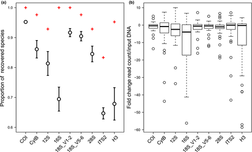

**Figure 1**

Comparative performance of the nine best primer pairs. (a) Proportion of 42 arthropod species that were recovered for the nine best primer pairs by either separate PCRs for each species (crosses) or PCRs on six mock communities with randomized amounts of each species (circles). The circles present the mean out of six mock communities and the bars the 95% confidence interval. (b) Fold change between proportion of input DNA and recovered sequence count for the same nine loci and 42 arthropod species. Boxes present median, upper and lower quartiles. The whiskers present the 1.5-fold interquartile range

We also found a high recovery rate of species from our mock communities of 42 mixed species (Figure 1a, Table S4). Most loci recovered over 80% of taxa from mock communities. Taxon recovery differences between loci were significant (Pairwise Wilcoxon test, FDR corrected *p* < 0.05). However, for many loci, the recovery of taxa from mixed communities was considerably lower than that achieved by separate amplification (Figure 1a).

Our newly designed primers for 12S and CytB showed considerable improvement in breadth and consistency of taxon recovery compared to established primers targeting the same loci (Barraclough et al., 1999; Kocher et al., 1989) (Pairwise Wilcoxon test, FDR corrected *p* < 0.05) (Figure S2, Table S5).

### Multiplex PCRs for multilocus phylogenetics and taxonomy in spiders

After quality filtering and read merging, we recovered 2,666 ± 1,604 sequences per spider specimen and locus on average. After OTU clustering, taxonomic assignment with BLASTn and sequence clean up, all specimens contained only a single sequence per locus. All tested loci showed a high recovery rate (Table S6). While H3 recovered only five of six spider families and five of seven genera, all other loci recovered sequences for more than 90% of the analysed families, genera and species.

The concatenated alignment of all nine loci amounted to 3,361 bp. Our phylogeny (Figure 2a) recovered three major divergent clades, corresponding to the so-called “RTA clade” (including Anyphaenidae, Philodromidae, Salticidae, Thomisidae, and Trachelidae), the Araneoidea (including Araneidae, Linyphiidae, Tetragnathidae, and Theridiidae) and the family Uloboridae. Within the genus *Tetragnatha*, we found two well-supported clades, which corresponded to the free-hunting “Spiny Leg” clade and the web-building species (Figure 2b). The generalist *T. hawaiensis* formed the basal clade to all other web-building species. The web-building species showed the repeated evolution of different web density phenotypes. Likewise, the Spiny Leg clade of free-hunting species showed repeated evolution of different ecomorphs: large brown, small brown, maroon and green ecomorphs (Gillespie, 2004). The overall pattern of relationships between taxa matched that of previous work, with the most basal Spiny Leg species being the green *T. kauaiensis* and some ecomorphs being phylogenetically clustered, e.g., a green clade (*T. brevignatha*, *T. macracantha* and *T. waikamoi*), and clades of large brown and small brown species.

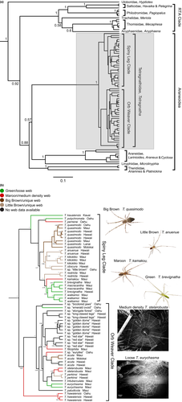

**Figure 2**

Intra- and interspecific distances for Hawaiian *Tetragnatha* were highly significantly different (Pairwise Wilcox Test, FDR corrected *p* < 0.001) for all seven tested loci (Figure 3). However, we did not recover a clear gap of intra- and interspecific distances for any locus (Figure 3, Table S7). The overlap of intra- and interspecific distances was most pronounced for nuclear loci, particularly 28S and H3. A higher separation of distances was found for the mitochondrial loci and nuclear ITS2. The highest inter- and intraspecific distances were found for mitochondrial COI and CytB. These two loci both supported almost the same divergence patterns, and no significant differences for intra- or interspecific distance between COI (Intra = 0.032; Inter = 0.130) and CytB (Intra = 0.029; Inter = 0.133) were found (Pairwise Wilcoxon test, *p* > 0.05). Significantly lower distances were found for 16S (Intra = 0.015; Inter = 0.078) and 12S (Intra = 0.012; Inter = 0.072). Even lower distances were found for the nuclear loci ITS2 (Intra = 0.015; Inter = 0.059), 28S (Intra = 0.005; Inter = 0.015) and H3 (Intra = 0.007; Inter = 0.023) (Pairwise Wilcoxon test, *p* < 0.05).

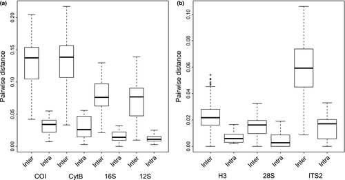

**Figure 3**

Comparison of intra- and interspecific pairwise genetic distances for 29 Hawaiian *Tetragnatha* species. For (a) four mitochondrial loci and (b) three nuclear loci

We found a significant correlation of intra- and interspecific pairwise genetic distances between COI and all other loci (Linear regression, *p* < 0.05; Figure 4, Table S7). All seven loci supported similar divergence patterns to COI between and within species. However, no locus showed a perfect association with COI. Relative to COI, each amplicon supported slightly different divergence patterns for pairwise comparisons, leading to a comparably wide spread of distance data points. As different loci showed different rates of evolution (Figure 4), we also found different slopes of their association with COI distances (Figure 4, Table S7).

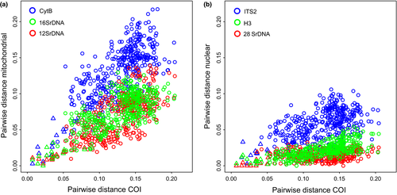

**Figure 4**

Intraspecific (triangles) and interspecific (circles) genetic distances between 29 Hawaiian *Tetragnatha* species. The *X* axis shows the pairwise distance for mitochondrial COI, and the *Y*-axis depicts the corresponding pairwise distances for (a) mitochondrial CytB, 16S and 12S and (b) nuclear ITS2, 28S and H3

The overlap between intra- and interspecific distances often differed between loci and species, i.e., a high intraspecific distance for one taxon and locus did not translate into the same pattern for other loci. In many cases, a combination of different loci emerged as a useful addition to a taxonomy based purely on COI data. For example, at 5.28%, the COI distance between *T. acuta* and *T. paludicola* was located at the overlap with intraspecific distances. CytB (13.78%) and 16S (7.29%) distances, however, were clearly within the interspecific range. Also, while the interspecific mitochondrial distance between *T. perkinsi* and *T. stelarobusta* was fairly low (COI = 4.21%; CytB = 3.33%; 16S = 2.72%; 12S = 1.24%), the distances for nuclear 28S (2.29%) and ITS2 (3.95%) fell well within the interspecific range.

## 4 DISCUSSION

### A cost efficient and simple approach to arthropod systematics

The flexibility of multiplex PCR assays makes it possible to extend them by using additional loci, for example to increase the number of nuclear genes for phylogenetics of a target lineage. Preliminary work also suggests that multiplex PCRs make it possible to recover the nine-locus dataset from bulk specimen pools, provided that a good reference database for all loci is available (Krehenwinkel unpublished data). This could lead to an additional drop in cost for library preparation. To generate comparable data using Sanger sequencing would require separate sequencing reactions for every locus and sequencing direction (at about $2.5 per sample), leading to a considerable increase of workload and raising the sequencing cost (excluding PCR and clean up reactions) for our nine locus dataset to $45 per sample.

The cost efficiency and ease of library preparation also make amplicon sequencing advantageous over alternative NGS-based approaches for taxonomy and systematics. Library preparation for target enrichment (McCormack et al., 2012), transcriptome sequencing (Misof et al., 2014), RAD sequencing (Peterson et al., 2012), or genome skimming (Dodsworth, 2015) all add levels of complexity, requiring extra steps of DNA shearing, digestion, ligation or hybridization. Moreover, these approaches require a considerably increased sequencing depth per specimen. However, compared to our nine-locus dataset, these methods will provide a much larger number of loci and thus allow phylogenetic and taxonomic analyses at higher support and resolution. Consequently, the method of choice depends on the aim of a research project. Due to its simplicity and cost efficiency, our amplicon sequencing approach will be very attractive for the phylogenetic and taxonomic analysis of large datasets of high taxonomic diversity, for example the contents of Malaise traps, or any study that includes broad taxonomic sampling. The increased resolution will enable researchers to derive more reliable estimates of species richness, but also of phylogenetic diversity (Graham & Fine, 2008). Moreover, our approach is well suited for fast, exploratory analysis on a limited set of taxa, e.g., as an alternative to Sanger sequencing. Our multiplexes could also serve as a method to generate “bait” sequences for genome skimming approaches (Crampton-Platt et al., 2015) targeted at assembling whole mitochondrial genomes or ribosomal clusters from community samples.

The work presented here was based on contemporary material of good DNA quality. However, our approach could also be useful for work on historical specimens, which often show pronounced DNA degradation (Kanda, Pflug, Sproul, Dasenko, & Maddison, 2015). The size of most amplicons we targeted is limited to 300–400 bp, and such short PCR fragments can still be amplified from degraded DNA samples. For example, previous work on spiders showed a good recovery of sequences of *c*. 300 bp from historical spider specimens of >100 years of age (Krehenwinkel & Pekar, 2015).

### Taxonomic and phylogenetic utility of multilocus datasets in spiders

Our multilocus dataset recovered well-supported phylogenies and taxonomic hypotheses. The inclusion of additional loci besides COI considerably improves the resolution of molecular systematic analyses (Ortiz & Francke, 2016). In particular, nuclear information is important, as mitochondrial divergence can be inflated by male-biased gene flow (Krehenwinkel et al., 2016) or infections with reproductive parasites (Hurst & Jiggins, 2005). Relationships between the different spider families generally matched known relationships based on phylogenomic analyses (Fernández, Hormiga, & Giribet, 2014), separating the “RTA clade”, Araneoidea and Uloboridae. The divergence within the “RTA clade” and the Araneoidea also mirrored current knowledge in spider phylogenetics (Dimitrov et al., 2017). Additionally, our approach allowed us to resolve shallow divergences between species as well as intraspecific variation, as shown by our analysis of the adaptive radiation in the genus *Tetragnatha*. The results supported previous work (Gillespie, Croom, & Palumbi, 1994) of an early divergence into two clades, one retaining the ancestral web-building behaviour, while the other developed into a free-hunting clade. The results also supported earlier findings that different ecomorphs of the Spiny leg clade evolved repeatedly on different islands (Gillespie, 2004) as have web forms among the web-building clade (Blackledge & Gillespie, 2004).

### The utility of loci for metabarcoding applications

All of the loci we presented here reliably recovered most species when separate PCRs were run for each taxon. However, only loci combining effective taxon recovery with low amplification bias across different taxa are well-suited for metabarcoding (Krehenwinkel, Wolf, et al., 2017). Several loci preferentially amplified certain taxa, leading to biased sequence abundances, loss of taxa from community sequencing, and skewed community diversity estimates. Consequently, primers need to be carefully evaluated for balanced amplification before they are used for metabarcoding applications. Different primers may also perform differently in multiplexes with bulk samples of different taxonomic compositions. Consequently, the relative benefits of a multiplex protocol and its optimization will need to carefully evaluated when bulk samples of varying taxon composition are amplified.

## 5 CONCLUSIONS

DNA barcoding based on mitochondrial COI allows reliable taxon identification, but the short COI barcoding amplicon is limited in situations where we seek to recover reliable phylogenetic signatures across a broad spectrum of taxa. While NGS approaches have facilitated the ability to generate large quantities of sequence data, costs of generating data across broad taxonomic scales is still prohibitive. Genome skimming is a popular approach to generate long multilocus datasets, e.g., whole mitochondrial genomes, though this method is still relatively expensive and creates large quantities of genomic DNA sequences that cannot be utilized for taxonomic or phylogenetic analyses. Here, we develop a protocol for amplicon sequencing of multiplex PCRs as a more targeted and cost-efficient approach to generate multilocus data that provides efficient results across a broad range of taxonomic levels, from orders to species. We introduce primer sets to amplify a total of *c*. 3,400 bp of nine nuclear and mitochondrial loci, that provide detailed phylogenetic signatures across a broad spectrum of relationships. Our approach is primarily focused on single biological specimens but may also be relevant to bulk or environmental samples using metabarcoding workflows. While a focus of our analysis lies on spiders, this approach will be useful for a wider range of taxa and can help to address the pressing need to characterize declining arthropod communities.

## ACKNOWLEDGEMENTS

We thank Charles Griswold for funding a sampling trip to Hawaii Island and for assisting with specimen collection. We acknowledge the Hawaii Department of Land and Natural Resources and the Nature Conservancy of Hawaii for granting us permission to sample arthropods in native rainforests. Brian Simison is acknowledged for giving us access to the MiSeq in California Academy of Sciences. H.K. was funded by a postdoctoral fellowship of the German Science Foundation (DFG). This work is funded by a National Science Foundation grant (NSF DEB 1241253) to R.G.G. The authors declare no conflict of interest.

## AUTHORS’ CONTRIBUTIONS

H.K., S.R.K. and A.R., devised the study, H.K., S.R.K., A.R., A.L. and R.G.G. performed field work and laboratory work, H.K. analysed the data. H.K., S.R.K., A.R. and R.G.G. wrote the manuscript.

## DATA ACCESSIBILITY

The following data supporting this article is available in the Dryad Digital Repository https://doi.org/10.5061/dryad.96712kh.

1. Sequence files for separate specimens and mock communities.
2. Alignments of all loci for all taxa.
3. Alignments used for primer design.
4. All data analysis tables.
5. A table of all primers tested in previous analyses.

## Citing Literature

[figure not shown]

November 2018

Pages 2181-2193